# The effects of wealth and other factors on obesity

Mai Phuong Pham Huynh, Judy Hao, Helen Hsu, Hayden Truong

4/29/2021

## 1. Load packages and prepare data set

To start with, we need to load the necessary packages and data sets. The data sets are obtained from The National Health and Nutrition Examination Survey (NHANES)’s 2017-2018 data wave. We will use the demographics data (DEMO_J.xpt), dietary data (DR1TOT_J.xpt), and body measures data (BMX_J.xpt).

```r
# Load package

library(Hmisc)
library(SASxport)
library(dplyr)
```

```r
library(tidyr)
library(forcats)
library(ggplot2)
library(plotly)
# Load data set

bmi <- read.xport('BMX_J.xpt')
demo <- read.xport('DEMO_J.xpt')
diet <- read.xport('DR1TOT_J.xpt')
```

We then join all the data sets above by respondents’ sequence numbers to get a complete and clean data set, consisting of BMI index, demographic, and dietary information of all respondents. The final and clean data set has 4479 observations after dropping 4775 missing data values.

```r
full <- full_join(bmi, demo, by= "SEQN")
full <- full_join(full, diet, by = "SEQN")
full <- full %>%
  select(BMXBMI,INDHHIN2,DMDEDUC2,DMDMARTL,DMDHHSZA,DMDHHSZB,DMDHHSZE,DR1TTFAT,DR1TSUGR) %>% # 9254
  drop_na() # 4479
summary(full)
```

```
##      BMXBMI         INDHHIN2        DMDEDUC2        DMDMARTL
##  Min.   :14.80   Min.   : 1.00   Min.   :1.000   Min.   : 1.000
##  1st Qu.:24.85   1st Qu.: 6.00   1st Qu.:3.000   1st Qu.: 1.000
##  Median :28.70   Median : 8.00   Median :4.000   Median : 2.000
##  Mean   :29.92   Mean   :12.08   Mean   :3.557   Mean   : 2.651
##  3rd Qu.:33.60   3rd Qu.:14.00   3rd Qu.:4.000   3rd Qu.: 5.000
##  Max.   :84.40   Max.   :99.00   Max.   :9.000   Max.   :77.000
##     DMDHHSZA         DMDHHSZB         DMDHHSZE        DR1TTFAT
##  Min.   :0.0000   Min.   :0.0000   Min.   :0.000   Min.   :  0.00
##  1st Qu.:0.0000   1st Qu.:0.0000   1st Qu.:0.000   1st Qu.: 51.10
##  Median :0.0000   Median :0.0000   Median :0.000   Median : 76.55
##  Mean   :0.2427   Mean   :0.5079   Mean   :0.708   Mean   : 85.25
##  3rd Qu.:0.0000   3rd Qu.:1.0000   3rd Qu.:1.000   3rd Qu.:108.03
##  Max.   :3.0000   Max.   :3.0000   Max.   :3.000   Max.   :567.96
##     DR1TSUGR
##  Min.   :  0.00
##  1st Qu.: 55.23
##  Median : 90.18
##  Mean   :106.73
##  3rd Qu.:137.10
##  Max.   :931.16
```

```r
full1 <- full
```

Based on the BMI index and the information from CDC, we factorized the BMI index, `BMXBMI`, into 4 levels: underweight (BMI < 18.5), normal (18.5 $\leq$ BMI < 25), overweight (25 $\leq$ BMI < 30), obesity ($\ge$ 30).

```r
full1$BMXBMI[full1$BMXBMI %in% seq(0.0,18.4,0.1)] <- "Underweight"
full1$BMXBMI[full1$BMXBMI %in% c(15.7,17.4,17.9,15.1,16.4)] <- "Underweight"
full1$BMXBMI[full1$BMXBMI %in% seq(18.5,24.9,0.1)] <- "Normal"
full1$BMXBMI[full1$BMXBMI %in% seq(25,29.9,0.1)] <- "Overweight"
full1$BMXBMI[full1$BMXBMI %in% seq(30,84.4,0.1)] <- "Obesity"
full1$BMXBMI <- as.factor(full1$BMXBMI)
summary(full1)
```

```
##          BMXBMI        INDHHIN2        DMDEDUC2        DMDMARTL
##  Normal     :1074   Min.   : 1.00   Min.   :1.000   Min.   : 1.000
##  Obesity    :1905   1st Qu.: 6.00   1st Qu.:3.000   1st Qu.: 1.000
##  Overweight :1433   Median : 8.00   Median :4.000   Median : 2.000
##  Underweight:  67   Mean   :12.08   Mean   :3.557   Mean   : 2.651
##                     3rd Qu.:14.00   3rd Qu.:4.000   3rd Qu.: 5.000
##                     Max.   :99.00   Max.   :9.000   Max.   :77.000
##     DMDHHSZA         DMDHHSZB         DMDHHSZE        DR1TTFAT
##  Min.   :0.0000   Min.   :0.0000   Min.   :0.000   Min.   :  0.00
##  1st Qu.:0.0000   1st Qu.:0.0000   1st Qu.:0.000   1st Qu.: 51.10
##  Median :0.0000   Median :0.0000   Median :0.000   Median : 76.55
##  Mean   :0.2427   Mean   :0.5079   Mean   :0.708   Mean   : 85.25
##  3rd Qu.:0.0000   3rd Qu.:1.0000   3rd Qu.:1.000   3rd Qu.:108.03
##  Max.   :3.0000   Max.   :3.0000   Max.   :3.000   Max.   :567.96
##     DR1TSUGR
##  Min.   :  0.00
##  1st Qu.: 55.23
##  Median : 90.18
##  Mean   :106.73
##  3rd Qu.:137.10
##  Max.   :931.16
```

## 2. Study income distribution

Now, we study the income distribution.

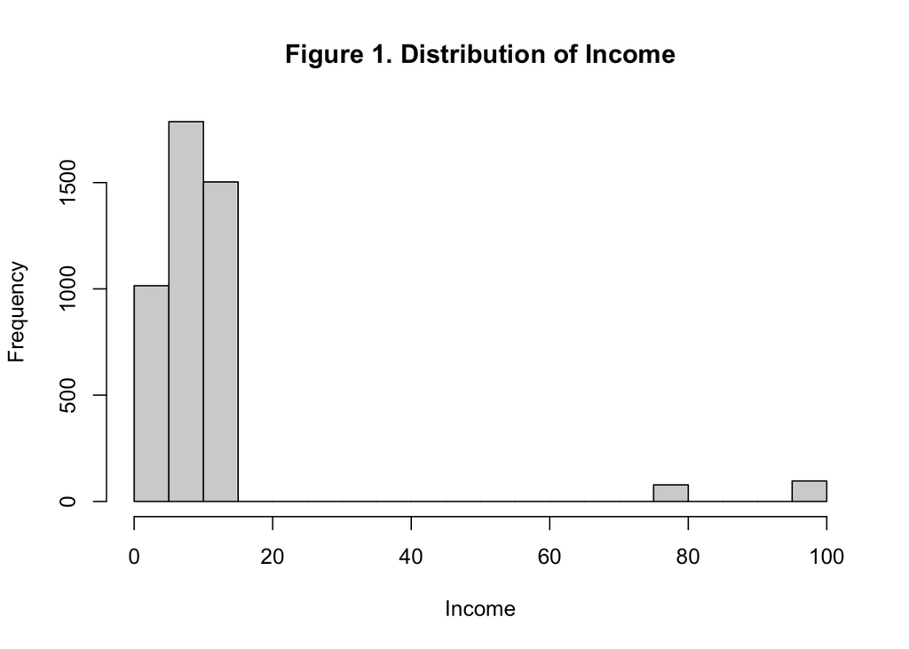

```r
hist(full$INDHHIN2, main = 'Figure 1. Distribution of Income', xlab = 'Income')
```

The histogram suggests us to factorize the income variable, `INDHHIN2`, into 4 levels: low income (0-5), middle lower income (6-10), middle upper income (11-15), and high income (>70).

```r
full1$BMXBMI <- as.numeric(full1$BMXBMI)
full1$INDHHIN2[full1$INDHHIN2 %in% c(1,2,3,4,5)] <- "Low Income"
full1$INDHHIN2[full1$INDHHIN2 %in% c(6,7,8,9,10)] <- "Lower Middle Income"
full1$INDHHIN2[full1$INDHHIN2 %in% c(11,12,13,14,15)] <- "Higher Middle Income"
full1$INDHHIN2[full1$INDHHIN2 %in% c(77,99)] <- "High Income"
full1$INDHHIN2 <- as.factor(full1$INDHHIN2)
```

First, let us see which income group contributes the most to the total population and which contributes the least.

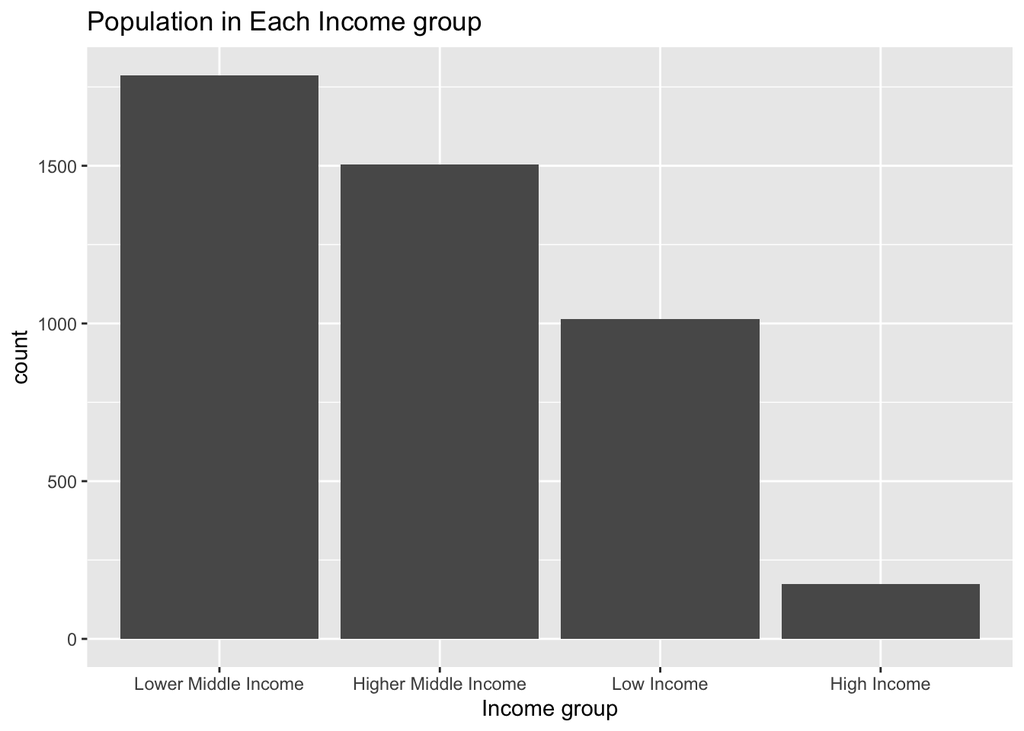

```r
full1 %>%
  mutate(INDHHIN2 = fct_infreq(INDHHIN2)) %>%
  ggplot(aes(INDHHIN2)) + geom_bar() +
  labs(title = 'Population in Each Income group',
       x = 'Income group')
```

Then, we study the relationship between income and BMI.

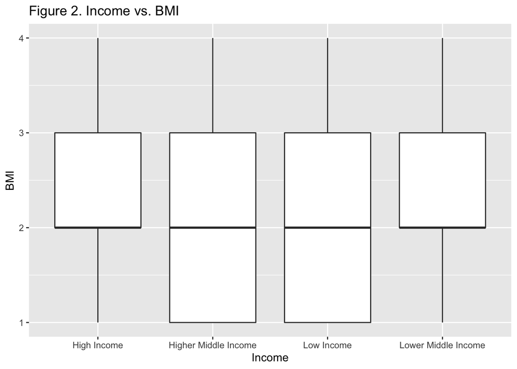

```r
ggplot(full1, aes(INDHHIN2,BMXBMI)) +
  geom_boxplot() +
  labs(title = 'Figure 2. Income vs. BMI', x = 'Income', y = 'BMI')
```

To have a more concrete information about the proportion of each weight level in an income group, we create a proportional table to calculate the percentage of underweight, normal, overweight, and obese people in each income group. From this table, we are able to create a bar plot to see how the proportions vary from among income groups.

```r
table1 <- table(full1$BMXBMI,full1$INDHHIN2)
table1
```

```
##
##     High Income Higher Middle Income Low Income Lower Middle Income
##   1          31                  393        259                 391
##   2          79                  570        420                 836
##   3          61                  523        311                 538
##   4           3                   17         25                  22
```

```r
table1df <- as.data.frame.matrix(table1)

pivot_longer(table1df, c('High Income', 'Higher Middle Income', 'Low Income', 'Lower Middle Income'), names_to = 'Income', values_to = 'Count')
```

```
## # A tibble: 16 x 2
##    Income               Count
##    <chr>                <int>
##  1 High Income             31
##  2 Higher Middle Income   393
##  3 Low Income             259
##  4 Lower Middle Income    391
##  5 High Income             79
##  6 Higher Middle Income   570
##  7 Low Income             420
##  8 Lower Middle Income    836
##  9 High Income             61
## 10 Higher Middle Income   523
## 11 Low Income             311
## 12 Lower Middle Income    538
## 13 High Income              3
## 14 Higher Middle Income    17
## 15 Low Income              25
## 16 Lower Middle Income     22
```

```r
table2 <- prop.table(table1,2)*100
table2
```

```
##
##     High Income Higher Middle Income Low Income Lower Middle Income
##   1   17.816092            26.147705  25.517241           21.880246
##   2   45.402299            37.924152  41.379310           46.782317
##   3   35.057471            34.797073  30.640394           30.106323
##   4    1.724138             1.131071   2.463054            1.231114
```

```r
table2 <- as.data.frame(table2)
table2
```

```
##    Var1                 Var2      Freq
## 1     1          High Income 17.816092
## 2     2          High Income 45.402299
## 3     3          High Income 35.057471
## 4     4          High Income  1.724138
## 5     1 Higher Middle Income 26.147705
## 6     2 Higher Middle Income 37.924152
## 7     3 Higher Middle Income 34.797073
## 8     4 Higher Middle Income  1.131071
## 9     1           Low Income 25.517241
## 10    2           Low Income 41.379310
## 11    3           Low Income 30.640394
## 12    4           Low Income  2.463054
## 13    1  Lower Middle Income 21.880246
## 14    2  Lower Middle Income 46.782317
## 15    3  Lower Middle Income 30.106323
## 16    4  Lower Middle Income  1.231114
```

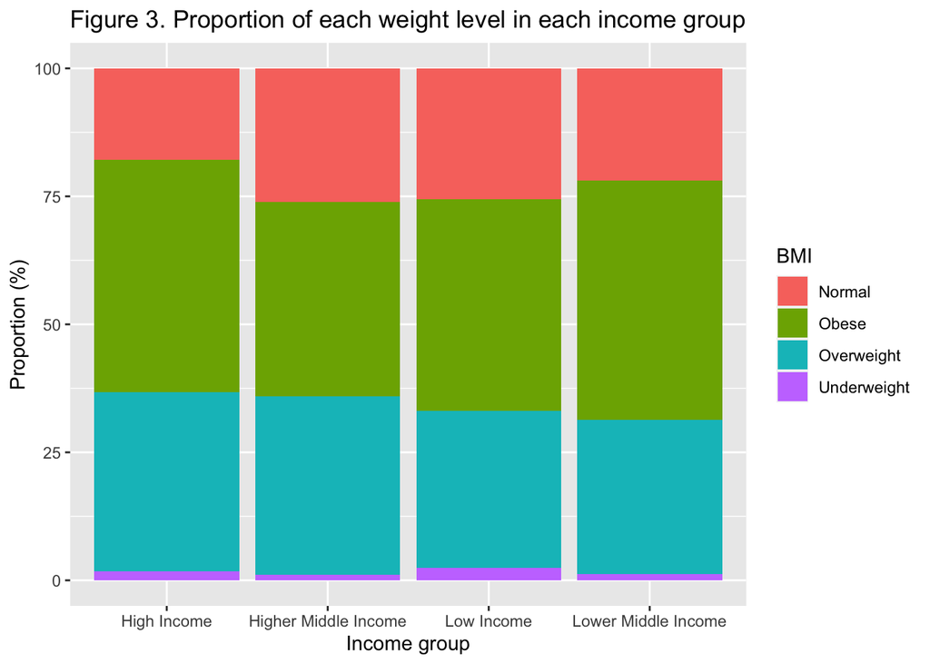

```r
names(table2)[1]<- 'BMI'

ggplot(table2, aes(x=Var2, y =Freq, fill=BMI)) +
  geom_bar(stat="identity") +
  labs(title = 'Figure 3. Proportion of each weight level in each income group',
       x = 'Income group', y = 'Proportion (%)') +
  scale_fill_discrete(name="BMI",
                         breaks=c("1", "2", "3", "4"),
                         labels=c("Normal", "Obese", "Overweight", "Underweight"))
```

From the proportional table and the barplot, we observe that for each weight level, the ascending order of the proportion of that weight level in each income group is as followed.

- Underweight (BMI < 18.5): Higher Middle < Lower Middle < High < Low
- Normal (18.5 $\leq$ BMI < 25): High < Lower Middle < Low < Higher Middle
- Overweight (25 $\leq$ BMI < 30): Lower Middle < Low < Higher Middle < High
- Obese ( BMI $\ge$ 30): Higher Middle < Low < High < Lower Middle

## 3. The impact of marital status and education level on obesity level

### a) Group 1. Low Income

We first look at the Low Income group (income index is no more than 5).

```r
# low income
low_inc <- full %>%
  filter(INDHHIN2 <= 5, DMDMARTL != 77, DMDEDUC2 != 7, DMDEDUC2 != 9)
summary(low_inc)
```

```
##      BMXBMI         INDHHIN2       DMDEDUC2        DMDMARTL       DMDHHSZA
##  Min.   :14.80   Min.   :1.00   Min.   :1.000   Min.   :1.00   Min.   :0.0000
##  1st Qu.:24.50   1st Qu.:3.00   1st Qu.:2.000   1st Qu.:1.00   1st Qu.:0.0000
##  Median :28.70   Median :4.00   Median :3.000   Median :3.00   Median :0.0000
##  Mean   :29.71   Mean   :3.48   Mean   :3.075   Mean   :3.12   Mean   :0.2419
##  3rd Qu.:33.70   3rd Qu.:5.00   3rd Qu.:4.000   3rd Qu.:5.00   3rd Qu.:0.0000
##  Max.   :84.40   Max.   :5.00   Max.   :5.000   Max.   :6.00   Max.   :3.0000
##     DMDHHSZB         DMDHHSZE         DR1TTFAT         DR1TSUGR
##  Min.   :0.0000   Min.   :0.0000   Min.   :  0.00   Min.   :  0.00
##  1st Qu.:0.0000   1st Qu.:0.0000   1st Qu.: 49.47   1st Qu.: 54.44
##  Median :0.0000   Median :1.0000   Median : 73.23   Median : 88.99
##  Mean   :0.3939   Mean   :0.6446   Mean   : 83.27   Mean   :111.83
##  3rd Qu.:0.0000   3rd Qu.:1.0000   3rd Qu.:103.51   3rd Qu.:143.96
##  Max.   :3.0000   Max.   :3.0000   Max.   :567.96   Max.   :621.55
```

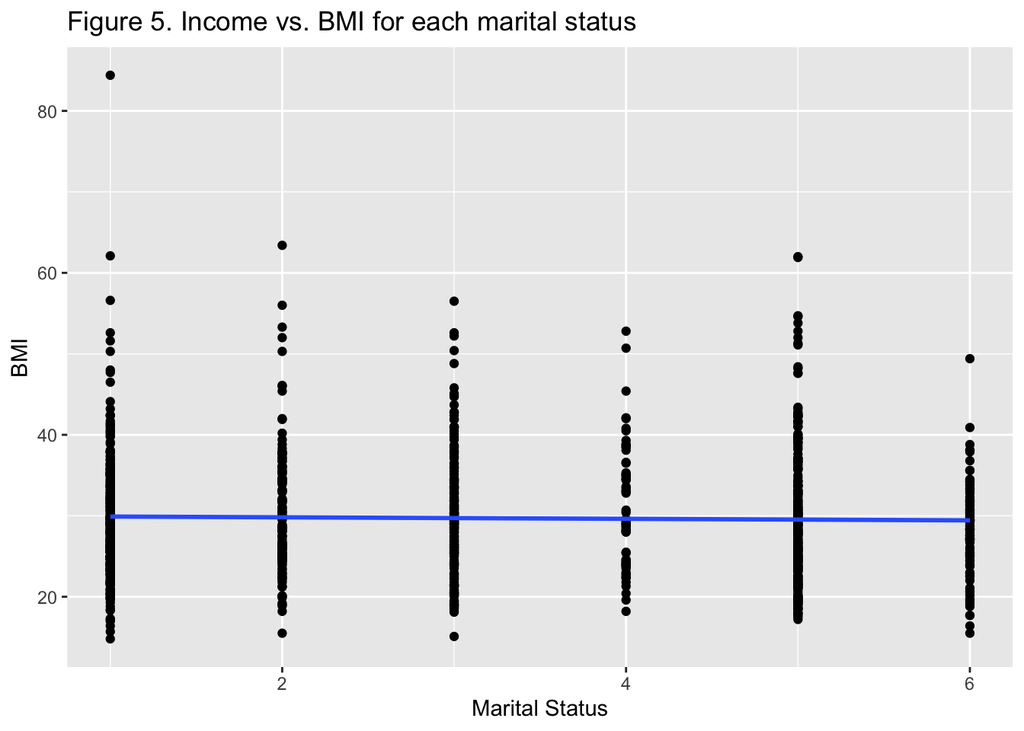

```r
# marital status
ggplot(low_inc, aes(DMDMARTL,BMXBMI)) +
  geom_point() +
  geom_smooth(method = 'lm', se=FALSE) +
  labs(title = 'Figure 5. Income vs. BMI for each marital status', x = 'Marital Status', y = 'BMI')
```

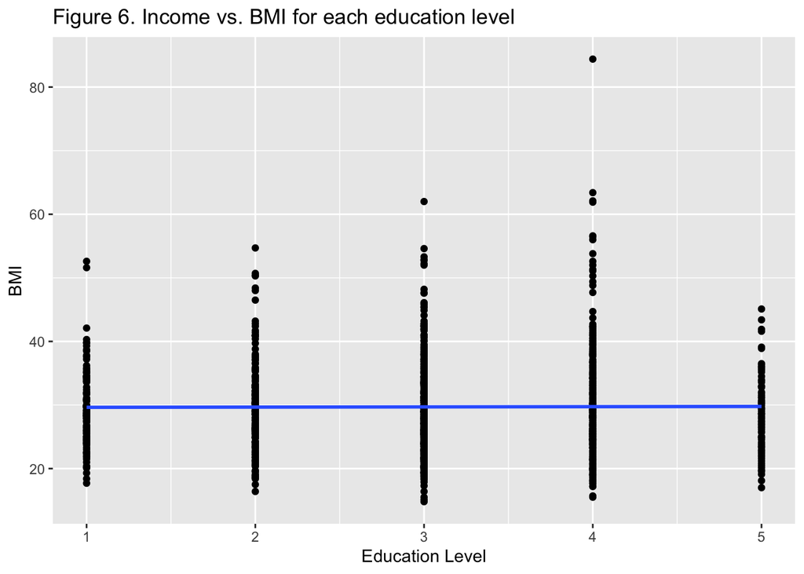

```r
#educ level
ggplot(low_inc, aes(DMDEDUC2,BMXBMI)) +
  geom_point() +
  geom_smooth(method='lm', se=FALSE) +
  labs(title = 'Figure 6. Income vs. BMI for each education level', x = 'Education Level', y = 'BMI')
```

The average BMI for low-income group is 29.71 and the median BMI is 28.7.

For this group, we do not observe the correlation between BMI and marital status. However, we remark that married people have the biggest range on BMI and that people living with partners have the smallest range on BMI.

### b) Group 2. Lower Middle Income

Then we looked at the Lower Middle Income group, in which the income index is greater than 5 and no more than 10.

```r
# low middle income
low_mid_inc <- full %>%
  filter(INDHHIN2 > 5 & INDHHIN2 <= 10, DMDMARTL != 77, DMDEDUC2 != 7, DMDEDUC2 != 9)
summary(low_mid_inc)
```

```
##      BMXBMI         INDHHIN2         DMDEDUC2        DMDMARTL
##  Min.   :15.70   Min.   : 6.000   Min.   :1.000   Min.   :1.000
##  1st Qu.:25.30   1st Qu.: 6.000   1st Qu.:3.000   1st Qu.:1.000
##  Median :29.30   Median : 7.000   Median :4.000   Median :1.000
##  Mean   :30.54   Mean   : 7.606   Mean   :3.439   Mean   :2.596
##  3rd Qu.:34.50   3rd Qu.: 9.000   3rd Qu.:4.000   3rd Qu.:5.000
##  Max.   :74.80   Max.   :10.000   Max.   :5.000   Max.   :6.000
##     DMDHHSZA         DMDHHSZB         DMDHHSZE         DR1TTFAT
##  Min.   :0.0000   Min.   :0.0000   Min.   :0.0000   Min.   :  0.21
##  1st Qu.:0.0000   1st Qu.:0.0000   1st Qu.:0.0000   1st Qu.: 49.53
##  Median :0.0000   Median :0.0000   Median :1.0000   Median : 76.56
##  Mean   :0.2671   Mean   :0.5252   Mean   :0.7632   Mean   : 84.43
##  3rd Qu.:0.0000   3rd Qu.:1.0000   3rd Qu.:1.0000   3rd Qu.:107.65
##  Max.   :3.0000   Max.   :3.0000   Max.   :3.0000   Max.   :415.24
##     DR1TSUGR
##  Min.   :  0.71
##  1st Qu.: 56.01
##  Median : 92.67
##  Mean   :107.76
##  3rd Qu.:138.73
##  Max.   :882.09
```

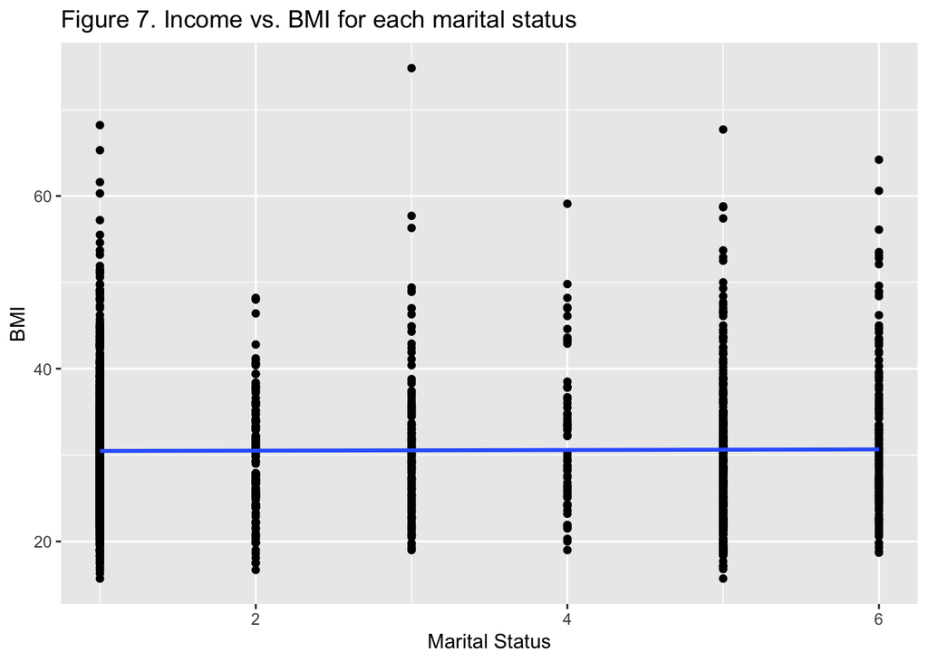

```r
ggplot(low_mid_inc, aes(DMDMARTL,BMXBMI)) +
  geom_point() +
  geom_smooth(method='lm', se=FALSE) +
  labs(title = 'Figure 7. Income vs. BMI for each marital status', x = 'Marital Status', y = 'BMI')
```

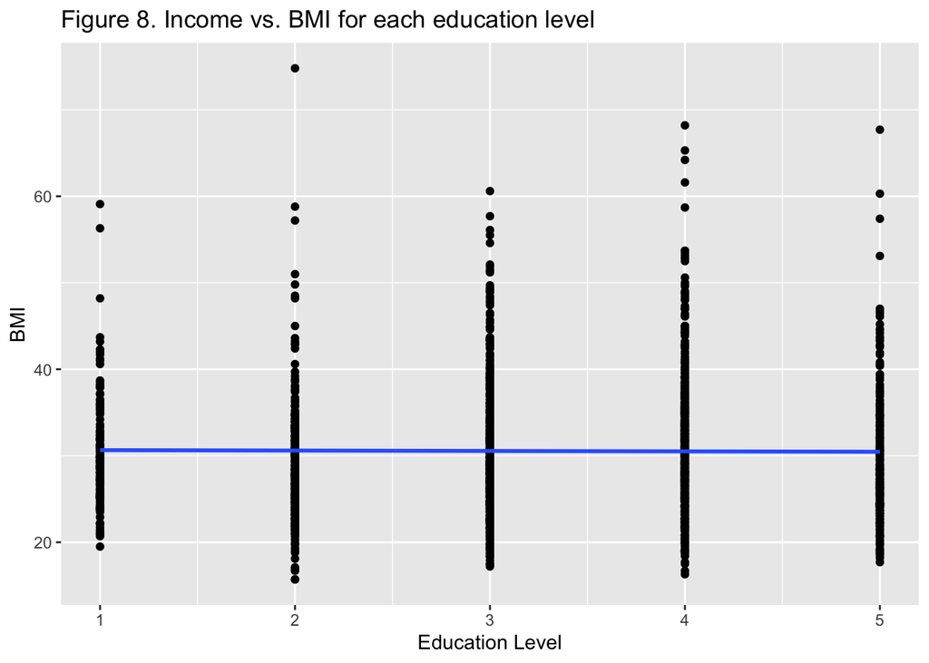

```r
ggplot(low_mid_inc, aes(DMDEDUC2,BMXBMI)) +
  geom_point() +
  geom_smooth(method='lm', se=FALSE) +
  labs(title = 'Figure 8. Income vs. BMI for each education level', x = 'Education Level', y = 'BMI')
```

The average BMI for Low Middle Income group is 30.54 and the median BMI is 29.3.

### c) Group 3. Upper Middle Income

Then we move on to the Upper Middle Income group, in which the income index is greater than 10 but no more than 15.

```r
# high middle income
high_mid_inc <- full %>%
  filter(INDHHIN2 > 10 & INDHHIN2 <= 15, DMDMARTL != 77, DMDEDUC2 != 7, DMDEDUC2 != 9)
summary(high_mid_inc)
```

```
##      BMXBMI         INDHHIN2       DMDEDUC2        DMDMARTL        DMDHHSZA
##  Min.   :16.20   Min.   :12.0   Min.   :1.000   Min.   :1.000   Min.   :0.000
##  1st Qu.:24.60   1st Qu.:14.0   1st Qu.:4.000   1st Qu.:1.000   1st Qu.:0.000
##  Median :27.90   Median :15.0   Median :4.000   Median :1.000   Median :0.000
##  Mean   :29.25   Mean   :14.3   Mean   :4.068   Mean   :2.205   Mean   :0.216
##  3rd Qu.:32.70   3rd Qu.:15.0   3rd Qu.:5.000   3rd Qu.:3.000   3rd Qu.:0.000
##  Max.   :64.70   Max.   :15.0   Max.   :5.000   Max.   :6.000   Max.   :3.000
##     DMDHHSZB         DMDHHSZE         DR1TTFAT         DR1TSUGR
##  Min.   :0.0000   Min.   :0.0000   Min.   :  0.00   Min.   :  0.60
##  1st Qu.:0.0000   1st Qu.:0.0000   1st Qu.: 55.19   1st Qu.: 54.64
##  Median :0.0000   Median :0.0000   Median : 78.60   Median : 87.97
##  Mean   :0.5473   Mean   :0.6947   Mean   : 87.96   Mean   :101.32
##  3rd Qu.:1.0000   3rd Qu.:1.0000   3rd Qu.:111.50   3rd Qu.:131.91
##  Max.   :3.0000   Max.   :3.0000   Max.   :536.10   Max.   :931.16
```

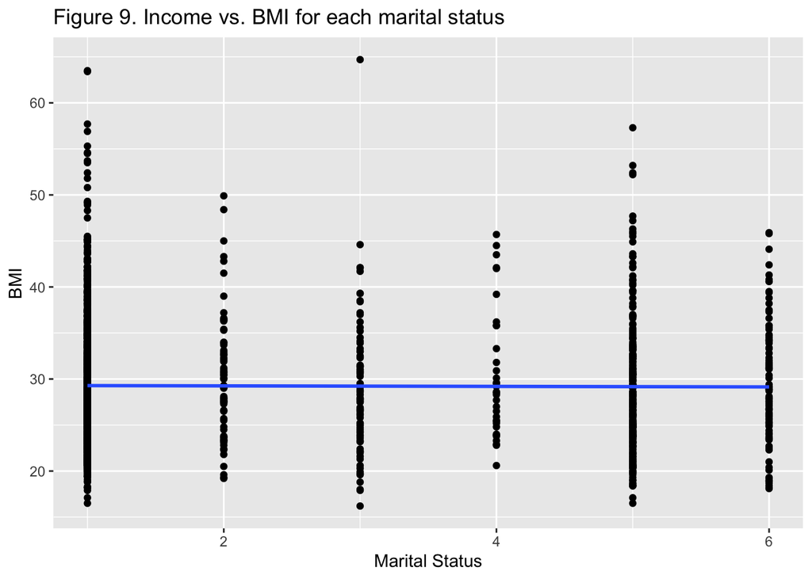

```r
ggplot(high_mid_inc, aes(DMDMARTL,BMXBMI)) +
  geom_point() +
  geom_smooth(method='lm', se=FALSE) +
  labs(title = 'Figure 9. Income vs. BMI for each marital status', x = 'Marital Status', y = 'BMI')
```

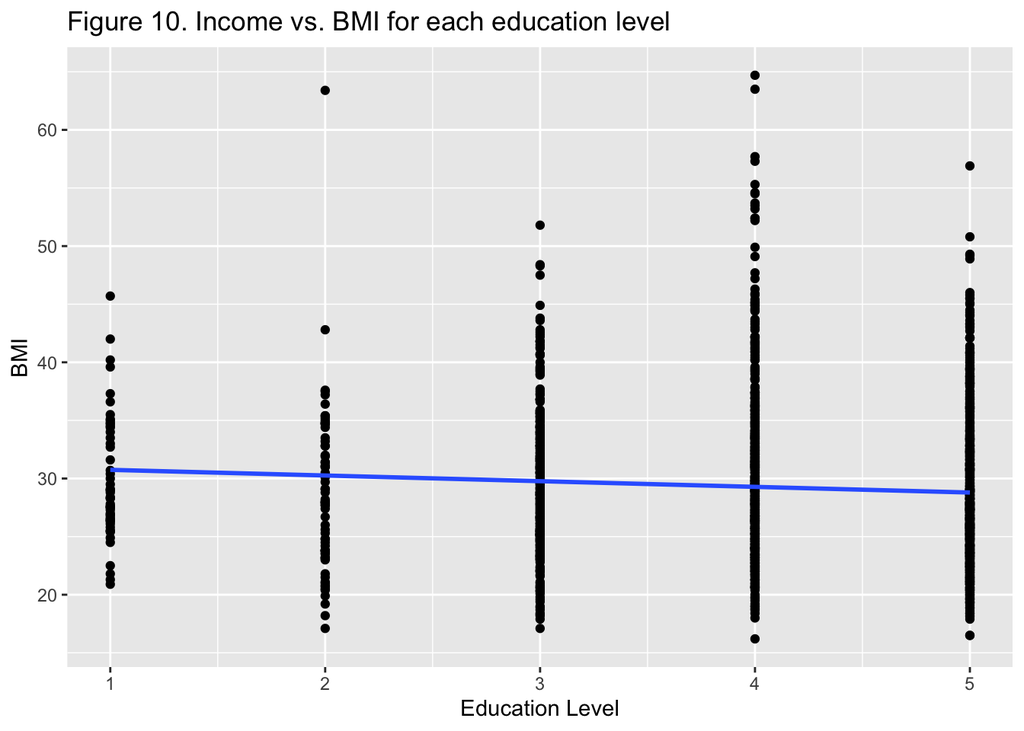

```r
ggplot(high_mid_inc, aes(DMDEDUC2,BMXBMI)) +
  geom_point() +
  geom_smooth(method='lm', se=FALSE) +
  labs(title = 'Figure 10. Income vs. BMI for each education level', x = 'Education Level', y = 'BMI')
```

The average BMI for Upper Middle Income group is 29.25 and the median BMI is 27.9.

On the other hand, we observe a slightly negative correlation between BMI and education level. The graph demonstrates that people with higher education degrees tend to have less BMI on average. This observation matches our hypothesis, in which we expect that more educated people are more conscious of their health and thus are less likely to suffer from obesity.

### d) Group 4. High Income

Finally, we look at the High Income group, in which the income index is greater than 15.

```r
# high income
rich <- full %>%
  filter(INDHHIN2 > 15, DMDMARTL != 77, DMDEDUC2 != 7, DMDEDUC2 != 9)
summary(rich)
```

```
##      BMXBMI         INDHHIN2        DMDEDUC2        DMDMARTL
##  Min.   :16.70   Min.   :77.00   Min.   :1.000   Min.   :1.000
##  1st Qu.:26.10   1st Qu.:77.00   1st Qu.:2.000   1st Qu.:1.000
##  Median :29.50   Median :99.00   Median :3.000   Median :3.000
##  Mean   :30.78   Mean   :89.21   Mean   :3.029   Mean   :3.006
##  3rd Qu.:34.10   3rd Qu.:99.00   3rd Qu.:4.000   3rd Qu.:5.000
##  Max.   :56.40   Max.   :99.00   Max.   :5.000   Max.   :6.000
##     DMDHHSZA        DMDHHSZB         DMDHHSZE         DR1TTFAT
##  Min.   :0.000   Min.   :0.0000   Min.   :0.0000   Min.   :  8.52
##  1st Qu.:0.000   1st Qu.:0.0000   1st Qu.:0.0000   1st Qu.: 49.86
##  Median :0.000   Median :0.0000   Median :0.0000   Median : 70.96
##  Mean   :0.237   Mean   :0.6647   Mean   :0.6012   Mean   : 82.71
##  3rd Qu.:0.000   3rd Qu.:1.0000   3rd Qu.:1.0000   3rd Qu.:107.61
##  Max.   :3.000   Max.   :3.0000   Max.   :3.0000   Max.   :236.96
##     DR1TSUGR
##  Min.   :  4.88
##  1st Qu.: 53.92
##  Median :101.72
##  Mean   :113.93
##  3rd Qu.:152.06
##  Max.   :493.37
```

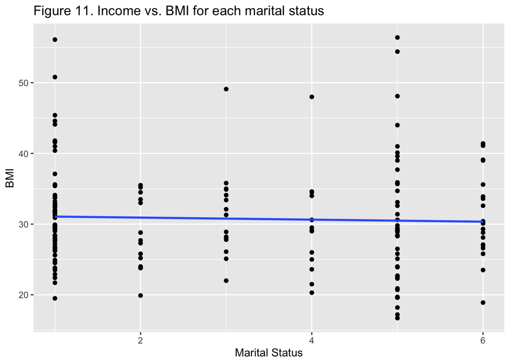

```r
ggplot(rich, aes(DMDMARTL,BMXBMI)) +
  geom_point() +
  geom_smooth(method='lm', se=FALSE) +
  labs(title = 'Figure 11. Income vs. BMI for each marital status', x = 'Marital Status', y = 'BMI')
```

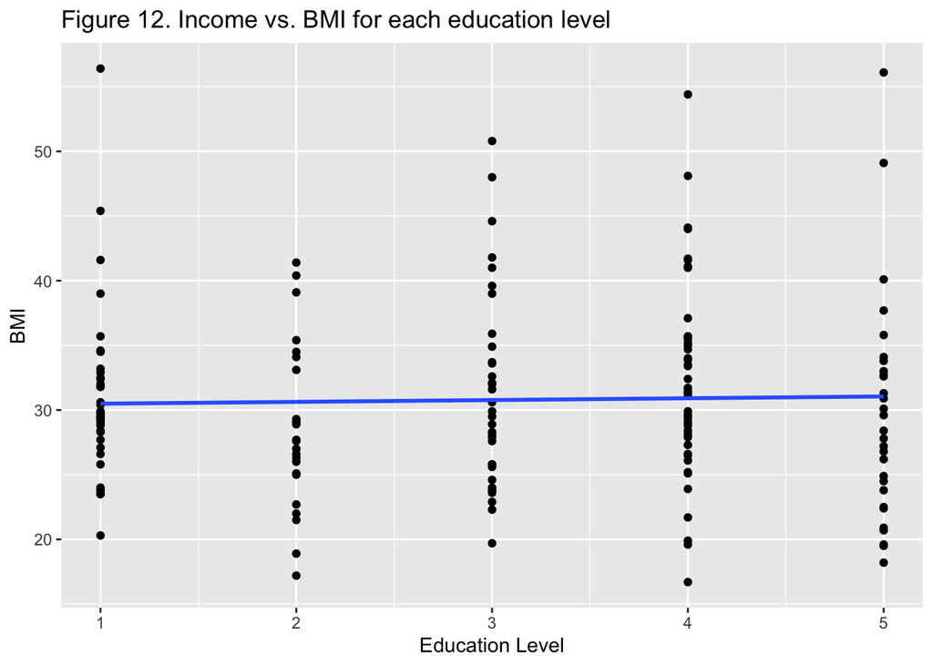

```r
ggplot(rich, aes(DMDEDUC2,BMXBMI)) +
  geom_point() +
  geom_smooth(method='lm', se=FALSE) +
  labs(title = 'Figure 12. Income vs. BMI for each education level', x = 'Education Level', y = 'BMI')
```

The average BMI for High Income group is 30.78 and the median BMI is 29.5.

For the High Income group, we discovered a slightly negative correlation between BMI and marital status. The plot illustrates that married people on average have a higher BMI than single people do. This finding matches our assumption that single people tend to take care of their health and thus are less likely to suffer from obesity.

On the other hand, we observed a slightly positive correlation between BMI and education level in the high-income group. This finding does not match our hypothesis, in which more educated people are less likely to be obese. The reason for this deviation might be that rich and educated people who care about their health may have excessive nutritious intakes, which would result in a higher average BMI.

## 4. Number of kids/elders in the household

In this section, we want to investigate the relationship between family structure and its corresponding obesity level. Our motivation is that families with more care-needed members (children and elders) are more likely to have lower rate of obesity. The rationale is that families with more children and elders tend to be more attentive to their diets. Based on the previous analysis, we expect that people from the High Income, Lower Middle Income, and Low Income groups will have the lowest number of family members that need special care as they have relatively high rate of overweight and obesity.

We first sum the variables `DMDHHSZA` (number of children 5 years or younger), `DMDHHSZB` (number of children 6-17 years old), and `DMDHHSZE` (number of adults 60 years or older) to represent the total number of people who need special care in the respondent’s household. Then, we calculate the average number of people with special care for each income group. This number is found to be highest for the Lower Middle Income group (1.555) and lowest for the Low Income group (1.280).

```r
low_inc1 <- low_inc %>%
  select(DMDHHSZA, DMDHHSZB, DMDHHSZE) %>%
  drop_na() %>%
  mutate(total= DMDHHSZA + DMDHHSZB + DMDHHSZE)
tot_lowinc = mean(low_inc1$total)
tot_lowinc
```

```
## [1] 1.280355
```

```r
low_mid_inc1 <- low_mid_inc %>%
  select(DMDHHSZA, DMDHHSZB, DMDHHSZE) %>%
  drop_na() %>%
  mutate(total= DMDHHSZA + DMDHHSZB + DMDHHSZE)
tot_lowmidinc = mean(low_mid_inc1$total)
tot_lowmidinc
```

```
## [1] 1.555431
```

```r
high_mid_inc1 <- high_mid_inc %>%
  select(DMDHHSZA, DMDHHSZB, DMDHHSZE) %>%
  drop_na() %>%
  mutate(total= DMDHHSZA + DMDHHSZB + DMDHHSZE)
tot_highmidinc = mean(high_mid_inc1$total)
tot_highmidinc
```

```
## [1] 1.458
```

```r
rich1 <- rich %>%
  select(DMDHHSZA, DMDHHSZB, DMDHHSZE) %>%
  drop_na() %>%
  mutate(total= DMDHHSZA + DMDHHSZB + DMDHHSZE)
tot_rich = mean(rich1$total)
tot_rich
```

```
## [1] 1.50289
```

The numbers found above does not meet our initial expectations. Hence, for future improvement, we want to look more closely into the inter-connection among income, family structure, and obesity level (measured by BMI index) by adding more indepedent variables into the model.